# Econ 184b, Econometrics, Fall 2021

### Module 1: Statistics Review

# Population and data: repeated sampling

Example 1: an abstract population

- Population: a Bernoulli distribution with mean $p$ = 0.5
- Data: a random sample of 54 observations from the above population/distribution
- How to think about the population and data?
- The above population is the distribution of a fair coin. A fair coin gives a random outcome of 1 (head) or 0 (tail) with equal probability.
- However, this does NOT mean that if you flip a fair coin 54 times, you will always get 27 heads and 27 tails! When you flip the coin 54 times, what you get is data: 54 binary numbers.

Try this in R:

```r
a = rbinom(54, 1, 0.5)
print(a)
mean(a)
# The rbinom function generates random numbers with the binomial distribution.
```

- In other words: data is a random realization from the population.
  - Goal of econometrics: learn the population from random data.
- From the data, we determine whether the data is from a fair coin.

Try this in R:

```r
a = rbinom(54, 1, 0.5)
b = rbinom(54, 1, 0.4)
mean(a)
mean(b)
```

# Example 2: a concrete population

Population: country of origin of all students at Brandeis (5771 students)

How to think about the population and data:

- Again, data is a random realization from the population.
- Goal of econometrics: learn the population from random data.
- Of course, if we are an administrator who observes the entire population, then there’s no need to do econometrics.

**Econometrics/statistics is only useful when we do not observe the population.**

# In many cases, we **never** observe the entire population

Example: population unemployment rate in the U.S.

- Goal: find out exactly what percentage of the people are unemployed.
- Population: employment status of everyone in the U.S. (over 300 million)
- Can we observe the population?
  - If we could send a drone to spy on every person in the U.S. and find out their employment status, then yes. But in practice, this cannot possibly be done.
- Data: interview 500 people and find out their employment status.
- How to think about the population and the data:
  - Population: 300 million numbers (either 1 “unemployed” or 0 “employed”).
  - This is represented by a Bernoulli distribution with mean p, where p is the percentage of 1 in these 300 million numbers.
  - Data: 500 random realization from the above Bernoulli distribution

# Probability distributions

- Notations
  - We will use R.V for the phrase “Random variable”.
  - Upper case letters (e.g., X and Y) denote R.V’s.
  - Lower case letters (e.g., a and b) denote non-random numbers (constants).
- Discrete R.V: a random variable that takes only a discrete set of values, like 0, 1, 2….
  - Example: Bernoulli R.V. (only takes value 0 and 1).
- Continuous R.V: a random variable that can take any value in a continuum.
  - Example: normal R.V. (can take any value in $\mathbb{R}$, the set of real numbers)
- The randomness of a R.V., $X$, can be fully summarized by the cumulative distribution function (cdf) of $X$:
  - $F(x)$ is a function of $x$ (non-random): $F(x)=Pr(X\leq x)$.
  - Notation: $Pr$ denotes the probability of an event.
  - $F(x)$ is non-decreasing: $F(1) \leq F(2)$.
- If the event $X\leq 1$ occurs, then $X\leq 2$ must occur. Therefore, $Pr(X\leq 1)$ ≤ $Pr(X\leq 2)$.
- If the cdf is differentiable, then the derivative is called the probability density function (pdf): $f(x) = dF(x)/dx$.
  - Discrete R.V. cannot have a differentiable cdf so discrete R.V. do not have a pdf.

Example: if X is a continuous R.V., how to compute $Pr(15<X\leq 20)$?

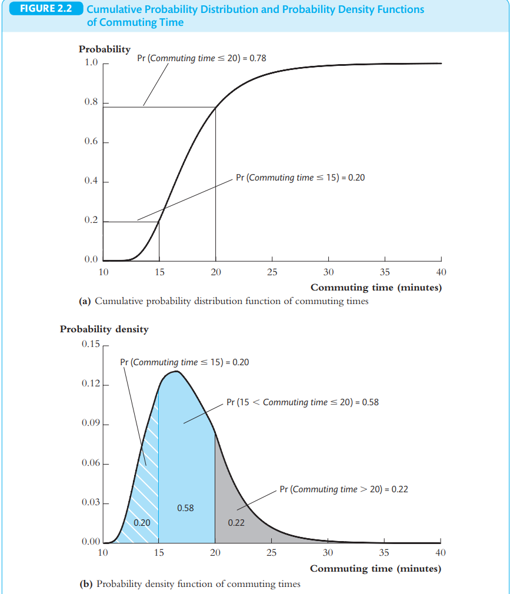

# Expected value or expectation or mean

Example: • Pr(𝑋 = 1) = 𝑝 and Pr(𝑋 = 0) = 1 − 𝑝. • Then 𝐸(𝑋) = 1 × 𝑝 + 0 × (1 − 𝑝) = 𝑝. So for Bernoulli variables, the probability of 𝑋 = 1 is the same as the mean 𝐸(𝑋). Example: • Possible values of 𝑋 are 3, 73 and 89 with the following distribution: Pr(𝑋 = 3) = 0.2 and Pr(𝑋 = 73) = 0.35 and Pr(𝑋 = 89) = 0.45 • Then 𝐸(𝑋) = 3 × 0.2 + 73 × 0.35 + 89 × 0.45 = 66.2